# Recetas electorales

Nelson Amaya

Twitter: [`@nelsonamayad`](https://twitter.com/NelsonAmayaD)  
Publicación: **24-04-2018**  
Última actualización: **28-08-2019**

> *Another feature we lose in going from logic to uncertainty is incrementality*  
> - [Judea Pearl](http://bayes.cs.ucla.edu/jp_home.html)

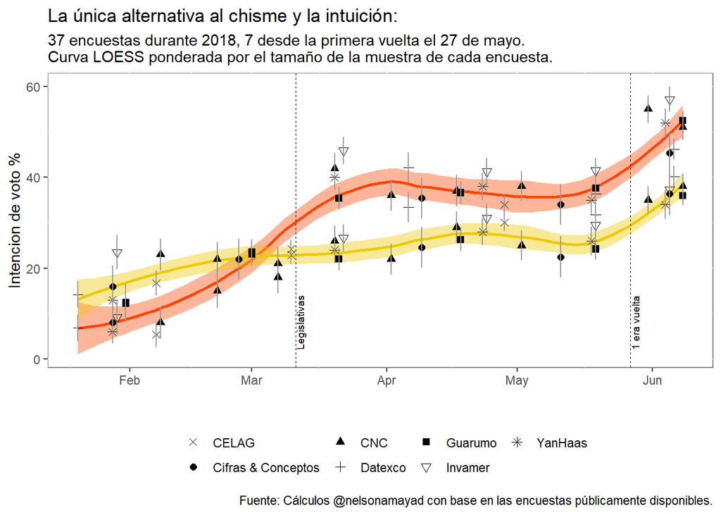

```r
library(RCurl)
library(tidyverse)

#1. Importar encuestas desde GitHub ####
encuestas <- read.csv(text=getURL("https://raw.githubusercontent.com/nelsonamayad/Elecciones-presidenciales-2018/master/Elecciones%202018/encuestas2018.csv"))

#2. Alistamiento #####
df <- encuestas %>% select(n,fecha, encuestadora,ivan_duque,gustavo_petro,sergio_fajardo,german_vargas_lleras, humberto_delacalle, margen_error, muestra)
df <- df %>% filter(as.Date(fecha, tz="GMT") >= as.Date('2018-01-01', tz="GMT"))
df <- df %>% rename(m_error = margen_error)
df <- df %>% select(-n) %>% gather(candidato, int_voto, ivan_duque,gustavo_petro,sergio_fajardo,german_vargas_lleras,humberto_delacalle)
df <- df %>% mutate(e_max = int_voto+m_error,e_min=int_voto-m_error,fecha=as.Date(fecha))
df <- df %>% transform(candidato=factor(candidato, levels=c("ivan_duque","gustavo_petro"
#,"sergio_fajardo","german_vargas_lleras","humberto_delacalle")
)))

resultado <- tribble(~fecha,~candidato,~int_voto,
      "2018-05-27","ivan_duque",39.14,
      #"2018-05-27","german_vargas_lleras",7.28,
      "2018-05-27","gustavo_petro",25.08
      #,"2018-05-27","sergio_fajardo",23.73,
      #"2018-05-27","humberto_delacalle",2.06
      )

# Caracteristicas graficas ####
shape_enc <- c(4,16,17,3,15,25,8)
subtitle <- c("37 encuestas durante 2018, 7 desde la primera vuelta el 27 de mayo. \nCurva LOESS ponderada por el tamaño de la muestra de cada encuesta.")
fuente <- c("Fuente: Cálculos @nelsonamayad con base en las encuestas públicamente disponibles.")
legis <-  geom_vline(xintercept=as.Date("2018-03-11"), size=0.1,linetype="dashed")
pv <-  geom_vline(xintercept=as.Date("2018-05-27"), size=0.1,linetype="dashed")

# 3 La grafica ####
df2 <- df %>% filter(candidato=="ivan_duque" | candidato=="gustavo_petro")
ggplot(df2,aes(x=fecha, y=int_voto)) +
  #Loess
  geom_smooth(aes(fill=candidato, color=candidato, weight=muestra), span=0.5,method="loess", show.legend = F) +
  #Encuestas
  geom_point(aes(shape=encuestadora, size=muestra_int_voto), size=2) +
  #Error
  geom_linerange(aes(ymax=e_max, ymin=e_min),color="grey60") +
  #Primera vuelta y legistlativas
  legis+annotate("text",x=as.Date("2018-03-12"),y=8,label="Legislativas",angle=90,size=2.5)+
  pv+annotate("text",x=as.Date("2018-05-28"),y=8,label="1 era vuelta",angle=90,size=2.5)+
  #Labs
  labs(x="",y="Intencion de voto %",
       title="La única alternativa al chisme y la intuición:",
       subtitle=subtitle,
       caption = fuente)+
  #Themes
  theme(legend.position="bottom",
        panel.background=element_rect(fill="white", color="grey50"),
        legend.title=element_blank(),
        legend.key=element_blank(),
        strip.text.x = element_text(size=10),
        strip.background=element_blank()) +
  #Facets
  #facet_wrap(~factor(candidato,levels=c("ivan_duque","gustavo_petro","sergio_fajardo","german_vargas_lleras","humberto_delacalle")),labeller=labeller(candidato=c("gustavo_petro"="Gustavo Petro", "ivan_duque"="Ivan Duque", "sergio_fajardo"="Sergio Fajardo","german_vargas_lleras"="German Vargas Lleras","humberto_delacalle"="Humberto de la Calle"
#)), nrow=1) +
  #Scales
  scale_color_manual(values=c("orangered","gold2"
                              #,"green4","red2","red4"
                              )) +
  scale_fill_manual(values=c("orangered","gold2"
                             #,"green4","red2","red4"
                             )) +
  scale_shape_manual(values=shape_enc)
```

## El menú:

1. [**Entrada - Locales 2019**](https://nelsonamayad.shinyapps.io/locales_2019): aplicación para ver las tendencias en la intención de voto para cada candidato de las elecciones de 3 principales ciudades según todas las encuestas públicamente disponibles. Preparada con [Shinyapps](https://www.shinyapps.io/).
2. [**Entrada - Presidenciales 2018**](https://nelsonamayad.shinyapps.io/col2018_tend/): aplicación para ver las tendencias en la intención de voto para cada candidato según todas las encuestas públicamente disponibles. Preparada con [Shinyapps](https://www.shinyapps.io/).
3. [**Aperitivo**](https://nelsonamayad.github.io/poder/poder): ¿qué pueden detectar las encuestas? ¿Son demasiado pequeñas para ser útiles? Un intento imperfecto de medir el poder estadístico de las encuestas. Preparado con [pwr](https://cran.r-project.org/web/packages/pwr/vignettes/pwr-vignette.html) en R.
4. [**Plato Simple**](https://nelsonamayad.github.io/simple/simple): primera receta para un modelo bayesiano lineal que sigue las pocas encuestas de intencion de voto. Permite un pronóstico básico pero limitado. Preparada con [Stan](http://mc-stan.org/users/interfaces/rstan.html).
5. [**Plato Mixto**](https://nelsonamayad.github.io/mixto/mixto): esta segunda receta es mejor que la primera, pero más complicada: introduce efectos aleatorios para interceptos y pendientes a la receta simple. Se ajusta mejor a los datos de las encuestas para todos los candidatos. Preparada con [Stan](http://mc-stan.org/users/interfaces/rstan.html).
6. [**Calentao de pronósticos**](https://nelsonamayad.github.io/calentao/calentao): Este es un plato con todos los pronósticos, promedios y modelos que encontré y que se publicaron antes de la primera vuelta. Incluye los resultados de los platos Simple y Mixto, los pronósticos de Cifras y Conceptos, ANIF, El País y un promedio entre las encuestas como referencia.
7. [**Caldo post electoral**](https://nelsonamayad.github.io/caldo/caldo): Comparación entre los pronósticos y los resultados a la primera vuelta. Ganadores: las encuestas y los platos [Simple](https://nelsonamayad.github.io/simple/simple) y [Mixto](https://nelsonamayad.github.io/mixto/mixto).
8. [**Postre logístico**](https://nelsonamayad.github.io/logis/logis): Un intento por hacer un pronóstico probabilístico para la segunda vuelta usando un modelo binomial. Preparado con [Stan](http://mc-stan.org/users/interfaces/rstan.html) y map2stan.

## ¿Qué se puede aprender de las encuestas?

[El que ignora las encuestas se pierde de mucho](https://nelsonamayad.github.io/caldo/caldo).

Algunos clarividentes saben la respuesta antes de que sea posible responderla. No dan lugar a la duda. Por ejemplo, [La Silla Vacía (LSV)](http://lasillavacia.com/blogs/la-carrera-de-caballos-en-la-silla-62772) es categórica sobre las encuestas: no se puede aprender nada de los sondeos.

Puede que LSV tenga razón: las encuestas se han descachado en casi todas las elecciones en las que se han utilizado para pronosticar el resultado. A veces se descachan en la dirección: en un ejercicio de estadística con las ganas, [The Upshot del New York Times le dió 85% de probabilidad de ganar a Hillary Clinton en la víspera de las elecciones de 2016](https://www.nytimes.com/interactive/2016/upshot/presidential-polls-forecast.html). Otras veces se descachan en tamaño: aunque las encuestas en Francia siempre dieron a Macron como ganador sobre Le Pen, [tuvieron un sesgo de más de 10 pp del resultado final](https://fivethirtyeight.com/features/macron-won-but-the-french-polls-were-way-off/).

Hay otra posibilidad, otra explicación a la posición de LSV. Es simple: los medios de comunicación [parecen ser incapaces de lidiar con probabilidades](https://fivethirtyeight.com/features/the-media-has-a-probability-problem/). Tienden a malinterpretar los datos, a clasificar como certero lo incierto y a simplificar indebidamente la información disponible para que quepa en una narrativa fácil de digerir. Dice LSV sobre las encuestas: “Nuestro razonamiento es que si en realidad *no son un instrumento totalmente confiable* para sondear la intención electoral de los colombianos, *cualquier análisis* que haga La Silla con base en ellas más que informar puede despistar” (énfasis añadido). Es comprehensible que los medios no sepan cómo escudriñar una encuesta, o cómo representar un pronóstico probabilístico; al fin y al cabo eso es difícil de hacer. Pero hay algo profundamente equivocado en creer que cualquier análisis que se haga sobre un instrumento imperfecto solo puede despistar o está hecho con ese propósito.

Otros medios como la revista Semana no han ni siquiera descubierto su propia ignorancia, ya que [parece que no son capaces de distinguir entre un promedio y una encuesta](https://www.semana.com/elecciones-presidenciales-2018/noticias/elecciones-presidenciales-la-encuesta-que-mide-todas-las-encuestas-559629).

Me gusta el trabajo de LSV, y [lo que han preparado para las elecciones es bueno](http://lasillavacia.com/elecciones2018#/la-maquinaria). Pero su racionalización sobre las encuestas es equivocada y perezosa.

Las encuestas son la única alternativa a la intuición y el chisme. Tienen errores, algunos explícitos y otros implícitos. Usan diferentes metodologías y estrategias muestrales, unas mejores que otras. Algunas revelan la tasa de respuesta; otras se la guardan. [Las muestras que toman son muy pequeñas para identificar señales silenciosas](https://nelsonamayad.github.io/poder/poder). Hay muchas razones para cuestionar, incluso desconfiar, de las encuestas. Pero hay más razones para desconfiar de analistas y columnistas: a la carreta casi nunca se le lleva contabilidad.

No creo que uno pueda criticar sin ofrecer una alternativa. Así que preparé un menú con bases estadísticas rigurosas, datos abiertos, código replicable y preparado con software open-source para hacerle seguimiento a las encuestas. **Es la única manera de hacer estadística creíble**. La idea es llenar un espacio, bueno, vacío: reconocer que en las encuestas puede haber información valiosa, y que sólo en conjunto se puede aproximar su valor, cualquiera que sea. Ese espacio no se puede llenar con [índices pomposos sin detalles](https://www.semana.com/opinion/articulo/la-volatilidad-de-las-preferencias-electorales-columna-de-juan-fernando-londono/562333), salsas secretas ni subterfugios estadísticos.

Este menú mejorará y cambiará con el paso del tiempo. Ahora mismo hay más recetas en el horno. Todas las recetas comparten la mismas características: acceso a los datos, el código sobre cómo se prepara cada plato, los detalles sobre cada supuesto utilizado, descripción de los modelos, estimaciones y resultados. Todo sobre la mesa.

Buen provecho.